# Practical 2: Processing Textual Data in R

Luka van der Plas, Mees van Stiphout, José de Kruif

Introduction to Text Mining with R

# Introduction

Welcome to the second practical of the course “Introduction to Text Mining with R”.

In this practical, we will work with text data, cleaning tools and try some visualizations.

As always we start with the packages we are going to use. Be sure to run these lines in your session to load the proper packages before you continue. If there are packages that you have not yet installed, first install them with `install.packages().

```r
library(tidyverse) # for data manipulation
```

```r
library(dplyr)     # for data manipulation
library(ggplot2)   # for visualization
library (SnowballC) # for stemming
library(tokenizers) # for tokenisation
library(tidytext)  # for counting words
library(wordcloud) # to create pretty word clouds
```

Before starting the exercises, you need to set your working directory to your Practicals folder. To this end, you can either create a project in RStudio and move the Rmd and data files to the project folder, or you can use the following line instead of creating a new project:

**Do not forget to adjust your working directory to the right folder.**

```r
# setwd("path/to/your/data")
```

# Reading data: CSV files

In this practical, we will be working with a dataset of book reviews from Goodreads. You can download the data from https://ayoubbagheri.nl/r_tm/#monday.

The data consists of two files: - `goodreads_english.csv` contains only reviews in English - `goodreads_mixed.csv` contains reviews in various languages

For now, we will be working with the English reviews.

1. **Use the `read.csv function to import the`goodreads_english.csv`and`goodreads_mixed.csv` files**

```r
goodreads_english <- read.csv("goodreads_english.csv", stringsAsFactors=FALSE)
goodreads_mixed <- read.csv("goodreads_mixed.csv", stringsAsFactors=FALSE)
```

We can inspect the first few lines to see what the data looks like.

```r
head(goodreads_english)
```

|  | book_title | language | rating | text |
| --- | --- | --- | --- | --- |
| 1 | Kringe in 'n bos | English | 5 | I read this book once back in 1986 while I was walking through the forests where this takes place. I then read it again in 2008. The magic of the book is in the setting - colonial days in a forest on … |
| 2 | Kringe in 'n bos | English | NA | Read for my book group. Very well researched and subject matter clearly close to the author's heart . Told it is better in original Afrikaans than in English, it reads easily but was nevertheless a li… |
| 3 | Kringe in 'n bos | English | 4 | I read this book at school. It was assigned to High Grade Afrikaans students. As a native South African, Saul related a lot to me. |
| 4 | Kringe in 'n bos | English | 5 | This affricaans language author from South Africa is excellent! Her works have obviously been translated into English, making her accessible not only to non-affricaans speakers in SA, but to the world… |
| 5 | Kringe in 'n bos | English | 5 | Saul Barnard comes from a long line of woodcutters in the Knysna forest of South Africa. Only Saul is different...he begins to question some of the lore and is accused of having his head in the clouds… |
| 6 | Kringe in 'n bos | English | 3 | Like the other two books by Dalene Matthee I've read it worthwhile when you are new in South Africa as I am. They provide wonderful descriptions of the famous Knysna forest and how people used to live… |

How many rows do we have?

```r
nrow(goodreads_english)
```

```
## [1] 10000
```

# Cleaning

We will go through a few common steps in text cleaning, where we make basic replacements in a text.

Let’s take one review as an example and see what we can do.

```r
example_text = goodreads_english[1, 'text']

example_text
```

```
## [1] "I read this book once back in 1986 while I was walking through the forests where this takes place. I then read it again in 2008. The magic of the book is in the setting - colonial days in a forest on the southern tip of Africa where the elephants hide."
```

## All words in lowercase

```r
tolower(example_text)
```

```
## [1] "i read this book once back in 1986 while i was walking through the forests where this takes place. i then read it again in 2008. the magic of the book is in the setting - colonial days in a forest on the southern tip of africa where the elephants hide."
```

## Clean up whitespace

The string below includes a double space, as well as a few newlines.

```r
some_text <- paste("I loved this book!", "It was  great.", "Looking forward  to the sequel.", sep="\n")
cat(some_text)
```

```
## I loved this book!
## It was  great.
## Looking forward  to the sequel.
```

What’s wrong with this? When we have a “clean” string, we can easily split the text into words by splitting on every space `" "`:

```r
strsplit("I loved this book!", " ")
```

```
## [[1]]
## [1] "I"     "loved" "this"  "book!"
```

But with a messy string, this gets tricky:

```r
strsplit(some_text, " ")
```

```
## [[1]]
##  [1] "I"               "loved"           "this"            "book!\nIt"
##  [5] "was"             ""                "great.\nLooking" "forward"
##  [9] ""                "to"              "the"             "sequel."
```

Let’s try to clean that up. The function `gsub` is the most basic way to make replacements in a string.

```r
gsub("bad", "good", "it was a bad book")
```

```
## [1] "it was a good book"
```

To remove something, we can just replace it with nothing:

```r
gsub("not", "", "I did not like the book")
```

```
## [1] "I did  like the book"
```

**Excercise 1:** try to clean up `some_text`: it should have no double spaces or newlines. To see if it works, try using `strsplit` on your result.

```r
oneline <- gsub("\n", " ", some_text)
cleaned <- gsub("  ", " ", oneline)

cleaned
```

```
## [1] "I loved this book! It was great. Looking forward to the sequel."
```

```r
strsplit(cleaned, " ")
```

```
## [[1]]
##  [1] "I"       "loved"   "this"    "book!"   "It"      "was"     "great."
##  [8] "Looking" "forward" "to"      "the"     "sequel."
```

## Remove numbers and punctuation

Removing numbers or punctuation is also a kind of replacement. To replace *all the numbers*, we could write some code like so:

```r
replaced <- example_text
replaced <- gsub("0", "", replaced)
replaced <-g sub("1", "", replaced)
replaced <-g sub("2", "", replaced)
# etc...
```

But this is way too much typing. Luckily, `gsub` also takes regular expressions, which we saw in the previous practical. If you have trouble understanding the expressions below, don’t worry too much about it. For now, the important thing is that regular expressions *can* be used to describe patterns like “all the numbers” or “periods, commas and hyphens”.

```r
gsub("[0-9]", "", example_text)
```

```
## [1] "I read this book once back in  while I was walking through the forests where this takes place. I then read it again in . The magic of the book is in the setting - colonial days in a forest on the southern tip of Africa where the elephants hide."
```

```r
gsub("[\\.,\\-]", "", example_text)
```

```
## [1] "I read this book once back in 1986 while I was walking through the forests where this takes place I then read it again in 2008 The magic of the book is in the setting  colonial days in a forest on the southern tip of Africa where the elephants hide"
```

## Putting it together

**Exercise 2:** combine all the steps we’ve used so far on `example_text`

```r
lowercase <- tolower(example_text)
no_numbers <- gsub("[0-9]", "", lowercase)
no_punct <- gsub("[\\.,\\-]", "", no_numbers)
oneline <- gsub("\n", " ", no_punct)
clean <- gsub("  ", " ", oneline)

clean
```

```
## [1] "i read this book once back in while i was walking through the forests where this takes place i then read it again in the magic of the book is in the setting colonial days in a forest on the southern tip of africa where the elephants hide"
```

As you can see, there are quite a few steps involved! However, these steps are very common, and as we will see, there are packages that make this easy for us.

# Tokenising

We already saw `strsplit` as a way to split a text into words, but that function is quite basic. From now on, we will use the `tokenizers` package to split our text into words. Let’s try running it with its default options:

```r
example_words <- tokenize_words(example_text)

example_words
```

```
## [[1]]
##  [1] "i"         "read"      "this"      "book"      "once"      "back"
##  [7] "in"        "1986"      "while"     "i"         "was"       "walking"
## [13] "through"   "the"       "forests"   "where"     "this"      "takes"
## [19] "place"     "i"         "then"      "read"      "it"        "again"
## [25] "in"        "2008"      "the"       "magic"     "of"        "the"
## [31] "book"      "is"        "in"        "the"       "setting"   "colonial"
## [37] "days"      "in"        "a"         "forest"    "on"        "the"
## [43] "southern"  "tip"       "of"        "africa"    "where"     "the"
## [49] "elephants" "hide"
```

As you can see, `tokenize_words` does a bit more than just tokenisation. For example, all the text is in lowercase now. Try running `help(tokenize_words)` to see all the options that the functions offers, and adjust `example_words` so it does not include `"1986"` and `"2008"`.

# Stemming

The `SnowballC` package allows us to stem words:

```r
wordStem(c("text", "texts", "texting"))
```

```
## [1] "text" "text" "text"
```

The `tokenize_words` function also has a handy variant, `tokenize_word_stems`, which uses the `snowballC` stemmer:

```r
tokenize_word_stems(example_text)
```

```
## [[1]]
##  [1] "i"        "read"     "this"     "book"     "onc"      "back"
##  [7] "in"       "1986"     "while"    "i"        "was"      "walk"
## [13] "through"  "the"      "forest"   "where"    "this"     "take"
## [19] "place"    "i"        "then"     "read"     "it"       "again"
## [25] "in"       "2008"     "the"      "magic"    "of"       "the"
## [31] "book"     "is"       "in"       "the"      "set"      "coloni"
## [37] "day"      "in"       "a"        "forest"   "on"       "the"
## [43] "southern" "tip"      "of"       "africa"   "where"    "the"
## [49] "eleph"    "hide"
```

## Stemming in other languages

`tokenize_word_stems` is based on English by default. We can get an overview with:

```r
getStemLanguages()
```

```
##  [1] "arabic"     "basque"     "catalan"    "danish"     "dutch"
##  [6] "english"    "finnish"    "french"     "german"     "greek"
## [11] "hindi"      "hungarian"  "indonesian" "irish"      "italian"
## [16] "lithuanian" "nepali"     "norwegian"  "porter"     "portuguese"
## [21] "romanian"   "russian"    "spanish"    "swedish"    "tamil"
## [26] "turkish"
```

**Exercise 3:** Use `tokenize_word_stems` on some Dutch text. Use `help` to see how you can adjust the language of the stemmer.

```r
example_dutch <- goodreads_mixed[14, "text"]
```

```r
#help("tokenize_word_stems")
```

```r
tokenize_word_stems(example_dutch, "dutch")
```

```
## [[1]]
##   [1] "hoewel"               "hij"                  "al"
##   [4] "op"                   "veertienjar"          "leeftijd"
##   [7] "zijn"                 "eerst"                "boek"
##  [10] "schref"               "begon"                "de"
##  [13] "zuid"                 "afrikan"              "deon"
##  [16] "meyer"                "pas"                  "na"
##  [19] "zijn"                 "dertigst"             "serieus"
##  [22] "over"                 "het"                  "schrijv"
##  [25] "van"                  "boek"                 "na"
##  [28] "te"                   "denk"                 "niet"
##  [31] "vel"                  "later"                "was"
##  [34] "zijn"                 "eerst"                "boek"
##  [37] "een"                  "feit"                 "de"
##  [40] "thriller"             "wie"                  "met"
```

[output cut: 181 more lines]

# Making a bag of words

We have only worked on an single review so far, but we want to work on our entire dataset. We will use `tidytext` to work with our data. Here we reshape our `goodreads_english` dataframe: each review is split over multiple rows, so we only have one word per row.

```r
goodreads_by_word <- goodreads_english %>%
  unnest_tokens(word, text)

head(goodreads_by_word)
```

|  | book_title | language | rating | word |
| --- | --- | --- | --- | --- |
| 1 | Kringe in 'n bos | English | 5 | i |
| 2 | Kringe in 'n bos | English | 5 | read |
| 3 | Kringe in 'n bos | English | 5 | this |
| 4 | Kringe in 'n bos | English | 5 | book |
| 5 | Kringe in 'n bos | English | 5 | once |
| 6 | Kringe in 'n bos | English | 5 | back |

Now we can use `count` to get the most common elements in the `word` column:

```r
goodreads_counts = goodreads_by_word %>%
  count(word, sort=TRUE)

goodreads_counts
```

| word | n |
| --- | --- |
| the | 71764 |
| and | 41190 |
| i | 39648 |
| to | 34714 |
| of | 34115 |
| a | 32170 |
| it | 23464 |
| in | 19450 |
| is | 19227 |
| this | 17612 |

[output cut: 9990 more lines]

Let’s try visualising our results in a wordcloud.

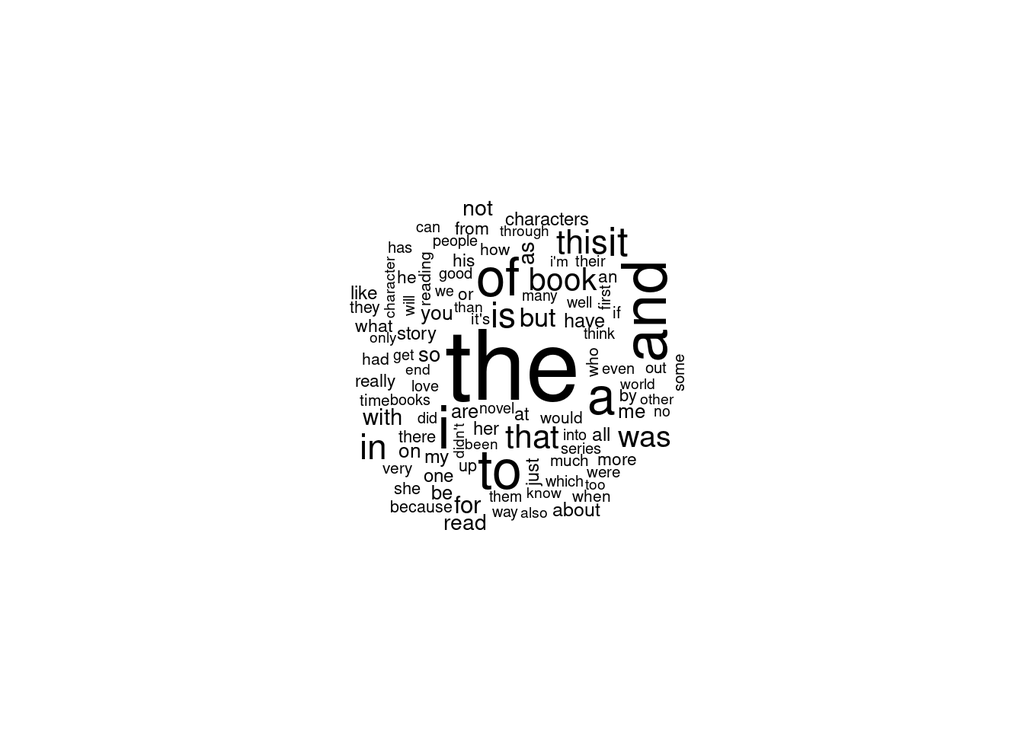

```r
goodreads_counts %>%
  with(wordcloud(word, n, max.words=100))
```

How many words are there in this dataset anyway? In text mining, we differentiate between *types* and *tokens*. The number of types tells us how many different words occur, and the number of tokens tells us how many words occur in total. For example, *“to be or not to be”* has 4 types (*to*, *be*, *or*, and *not*), and 6 tokens (*to*, *be*, *or*, *not*, *to*, and *be*).

**Exercise 4:** How many types are in `goodreads_counts`? And how many tokens?

```r
# number of types
nrow(goodreads_counts)
```

```
## [1] 30839
```

```r
#number of tokens
sum(goodreads_counts['n'])
```

```
## [1] 1326809
```

**Exercise 5:** The `unnest_tokens` that we used above takes the same arguments as `tokenize_words`: you can tweak whether you want to turn everything into lowercase and whether to clean up punctuation or numbers. Create a new table where you adjust one of these options, and report on how it affects the number of types and tokens.

```r
goodreads_count_no_lowercasing <- goodreads_english %>%
  unnest_tokens(word, text, to_lower=FALSE) %>%
  count(word)

print('Number of types:')
```

```
## [1] "Number of types:"
```

```r
print(nrow(goodreads_count_no_lowercasing))
```

```
## [1] 36137
```

```r
print('Number of tokens:')
```

```
## [1] "Number of tokens:"
```

```r
print(sum(goodreads_count_no_lowercasing['n']))
```

```
## [1] 1326809
```

```r
# we can see that lowercasing does not affect the number of tokens, but it did lower the number of types
```

# Remove stopwords

The wordcloud we made in the previous section is nice, but it contains a lot of generic words like “the”, “and”, etc. Let’s try removing stopwords.

We will use `get_stopwords` from the `tidytext` package to get a list of stopwords in English.

```r
stopwords_english <- get_stopwords()
stopwords_english
```

| word | lexicon |
| --- | --- |
| i | snowball |
| me | snowball |
| my | snowball |
| myself | snowball |
| we | snowball |
| our | snowball |
| ours | snowball |
| ourselves | snowball |
| you | snowball |
| your | snowball |

[output cut: 165 more lines]

Now, we want to exclude these from our table of words. We can use `anti_join`, which means that we cross-reference with another table, and remove everything that is also in the other table. Then, we use `count` again to get a new frequency table.

```r
goodreads_without_stopwords <- goodreads_by_word %>%
  anti_join(stopwords_english, by='word') %>%
  count(word, sort=TRUE)

head(goodreads_without_stopwords)
```

|  | word | n |
| --- | --- | --- |
| 1 | book | 15793 |
| 2 | read | 7894 |
| 3 | like | 5337 |
| 4 | story | 5238 |
| 5 | one | 5219 |
| 6 | characters | 5151 |

This already looks a lot more informative: the most frequent words include *book*, *read* *story*, and *characters*: they tell us something about what this dataset is about. We can make another wordcloud that does not include the stopwords:

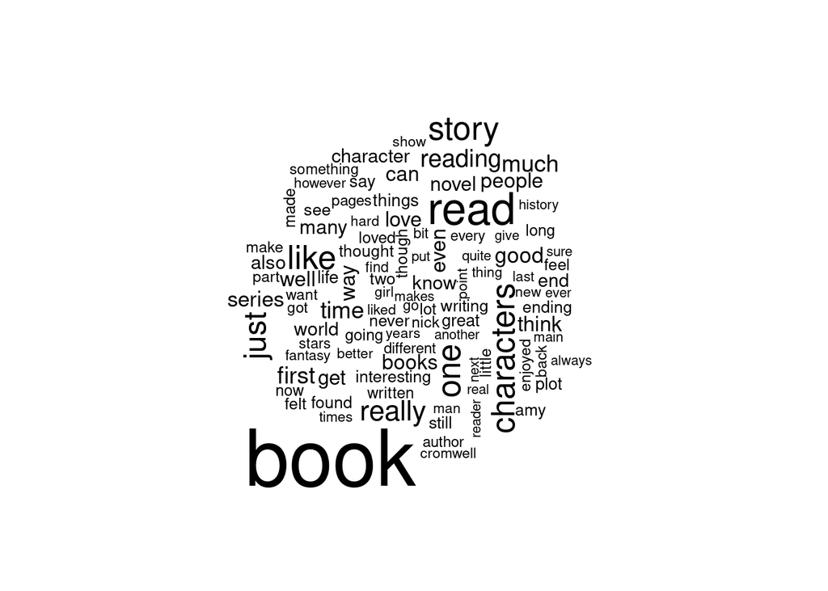

```r
goodreads_without_stopwords %>%
  with(wordcloud(word, n, max.words=100))
```

**Exercise 6:** We can use `filter`to select the reviews from a specific book, like so. Make a word cloud for the reviews of *Nineteen eighty-four* and *Gone girl* and compare them side-by-side. Do they look very different?

```r
goodreads_english %>%
  filter(book_title == "Nineteen eighty-four")
```

| book_title | language | rating | text |
| --- | --- | --- | --- |
| Nineteen eighty-four | English | 4 | Wow. My first time through this one. What a concept though. I really enjoyed the story, but I have mixed feelings about the ending. |
| Nineteen eighty-four | English | 5 | This book should be read by everyone at least once. It should also be considered a non fiction, George Orwell perfectly captures and predicts the political climate of not only his time but what he bel… |
| Nineteen eighty-four | English | 4 | A Classic on the importance of collective memory and the influence of the use of language on our ability to form complex thoughts, ideas and to develop critical thinking. Timeless. |
| Nineteen eighty-four | English | 4 | Quotes: Either the future would resemble the present, in which case it would not listen to him: or it would be different from it, and his predicament would be meaningless. The past was dead, the futur… |
| Nineteen eighty-four | English | 3 | I love the high vocabulary of this book. It had long been on the bucket list, but I admit it was not what I expected. It was the darker version of a Brave New World and F-451. At times there was too m… |
| Nineteen eighty-four | English | 5 | the most horrifying and atrocious fictional world i have ever read |
| Nineteen eighty-four | English | 5 | Frightening how prophetic Orwell was. I kept thinking of my work environment and how this is a nearly perfect description of the overall atmosphere and how things are run from "Big Brother" |
| Nineteen eighty-four | English | 5 | Alan Moore, the writer of comics has once said: “Now, as I understand it, the bards were feared. They were respected, but more than that they were feared. If you were just some magician, if you'd piss… |
| Nineteen eighty-four | English | 5 | Important Read for these times I periodically read this book to remind myself how fragile our freedom is regardless of the party in power. For example politically correct speech is one step from the N… |
| Nineteen eighty-four | English | 4 | I have been wanting to read this book since I read Animal Farm 4-5 years ago. I enjoyed this book just a little less and would rate it a 3.5. If you want to read a book that gives you the willies then… |

[output cut: 934 more lines]

# POS tagging

`tidytext` provides a table `parts_of_speech` which lists potential parts of speech for English words. We can use this for a very basic way of assigning a POS to each word, by looking up each word in the table. Here we do just that: `left_join` means that for each row in `goodreads_by_word`, we look up the corresponding row in `parts_of_speech` and combine the data.

```r
goodreads_pos <- goodreads_by_word %>%
  left_join(parts_of_speech, by="word", multiple="first")

head(goodreads_pos)
```

|  | book_title | language | rating | word | pos |
| --- | --- | --- | --- | --- | --- |
| 1 | Kringe in 'n bos | English | 5 | i | Noun |
| 2 | Kringe in 'n bos | English | 5 | read | Noun |
| 3 | Kringe in 'n bos | English | 5 | this | Definite Article |
| 4 | Kringe in 'n bos | English | 5 | book | Noun |
| 5 | Kringe in 'n bos | English | 5 | once | Adverb |
| 6 | Kringe in 'n bos | English | 5 | back | Noun |

Be aware that this is a very crude way of assigning POS tags. We usually want to take the rest of the sentence into account, so we can differentiate between two sentences like:

- *I want to **read** this book.*
- *This book is a great **read**.*

You can see this going wrong in the table above: “read” is classified as a noun instead of a verb. However, we can accept a some inaccuracy for our purposes here.

**Exercise 7:** Try using `filter` to only get a table containing only adjectives. Then filter on the rating so you can compare the adjectives used in the highest ratings (5) with those used in the lowest ratings (1). Make a wordcloud for both.

```r
goodreads_adjectives <- goodreads_pos %>%
  filter(pos == "Adjective")
```

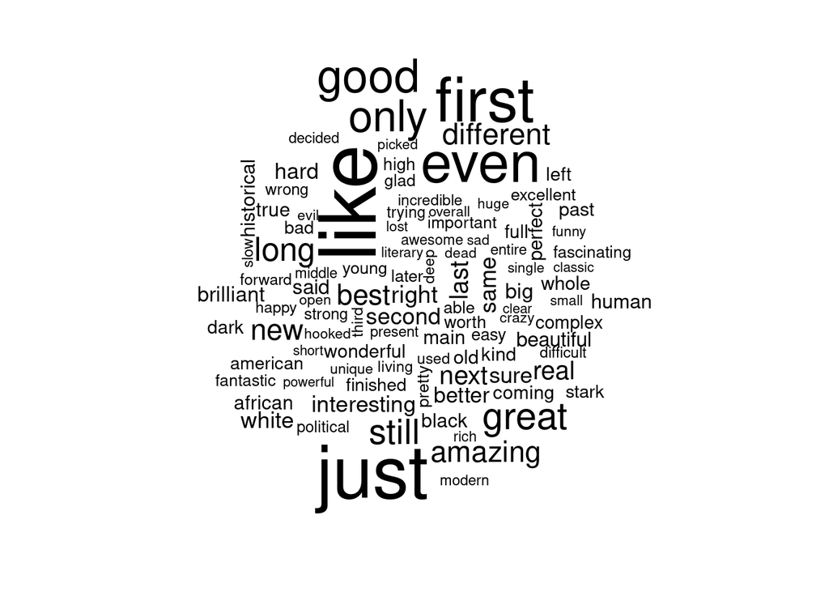

```r
goodreads_adjectives %>%
  filter(rating == 5) %>%
  count(word, sort=TRUE) %>%
  with(wordcloud(word, n, max.words=100))
```

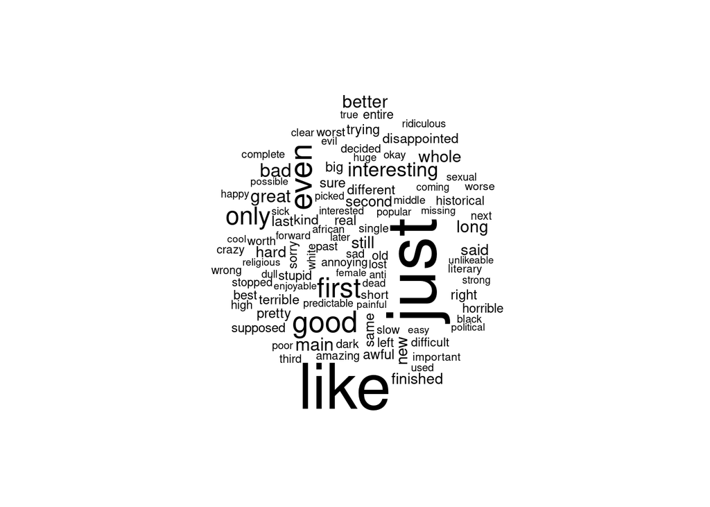

```r
goodreads_adjectives %>%
  filter(rating == 1) %>%
  count(word, sort=TRUE) %>%
  with(wordcloud(word, n, max.words=100))
```

# Mixed-language data

`goodreads_mixed` contains reviews in a mix of languages. We can see how many reviews we have for each:

```r
goodreads_mixed %>%
  count(language, sort=TRUE)
```

| language | n |
| --- | --- |
| Spanish | 5042 |
| Italian | 1970 |
| German | 872 |
| Dutch | 860 |
| French | 681 |
| Arabic | 197 |
| Afrikaans | 191 |
| Swedish | 187 |

**Exercise 8:** Filter the Spanish reviews (or pick another language, if you like). Go through the preprocessing steps we have covered so far and visualise the results. Think about which steps would need to be adjusted based on the language, and adjust them accordingly.

```r
# filter reviews
goodreads_spanish <- goodreads_mixed %>%
  filter(language == "Spanish")

head(goodreads_spanish)
```

|  | book_title | language | rating | text |
| --- | --- | --- | --- | --- |
| 1 | Fiela se kind | Spanish | NA | Enjoyable read. |
| 2 | Persomi | Spanish | 5 | Very enjoyable read! |
| 3 | The no. 1 ladies' detective agency | Spanish | 4 | Una historia diferente. Se trata de una mujer que se instala como detective privado en Botswana. Me encanta el personaje de Mma Ramotswe, una mujer africana, rellena, llena de ternura. AdemÃ¡s es exce… |
| 4 | The no. 1 ladies' detective agency | Spanish | 2 | Me temo que esta "recopilación" de relatos cortos e historias insulsas me ha parecido ñoña y aburrida, pero por prurito personal (sí, me han salido granos) he conseguido acabarla. Al final hasta parec… |
| 5 | The no. 1 ladies' detective agency | Spanish | 5 | Me atrapó desde la primera página. Una visión de lo cotidiano en Africa, con mucho amor y disfrutando de las cosas sencillas. Me encanta, seguiré con la serie. |
| 6 | The no. 1 ladies' detective agency | Spanish | 4 | Entretenida serie de relatos que tiene como protagonista a Mma Ramotswe, la primera detective de Botswana. |

```r
# tokenise
goodreads_spanish_words <- goodreads_spanish  %>%
  unnest_tokens(word, text)

head(goodreads_spanish_words)
```

|  | book_title | language | rating | word |
| --- | --- | --- | --- | --- |
| 1 | Fiela se kind | Spanish | NA | enjoyable |
| 2 | Fiela se kind | Spanish | NA | read |
| 3 | Persomi | Spanish | 5 | very |
| 4 | Persomi | Spanish | 5 | enjoyable |
| 5 | Persomi | Spanish | 5 | read |
| 6 | The no. 1 ladies' detective agency | Spanish | 4 | una |

```r
# remove stopwords
goodreads_spanish_words_clean <- goodreads_spanish_words %>%
  anti_join(get_stopwords(language="es"), by="word")
```

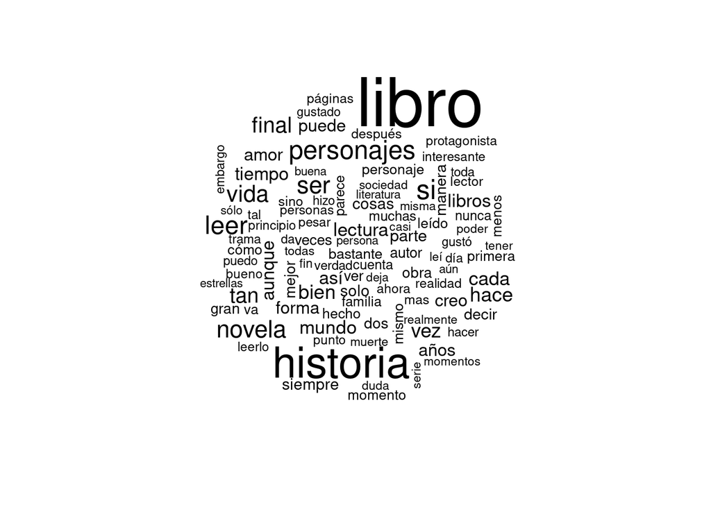

```r
goodreads_spanish_words_clean %>%
  count(word) %>%
  with(wordcloud(word, n, max.words=100))
```